# Exploratory Data Analysis on Movie Dataset

The Herd - Jan Anders, Varsha Budihal, Shraddha Bhvarsar, Rachel Gonzales

April, 2019

### This document features all analysis we have conducted on our dataset, even if the results were not included in our paper due to it getting to long. There sometimes is some commentary on the results, however, we want to refer to the paper for more explanations.

# Intro

We will first import the data and make a few checks, before we start our analysis. Also, we will add the column “profit”

```r
movies <- read.csv("C:/Users/Admin/Documents/movies.csv")
movies <- movies %>% mutate(profit = gross - budget)
str(movies)
```

```
## 'data.frame':    6820 obs. of  16 variables:
##  $ budget  : int  8000000 6000000 15000000 18500000 9000000 6000000 25000000 6000000 9000000 15000000 ...
##  $ company : Factor w/ 2179 levels "\"DIA\" Productions GmbH & Co. KG",..: 665 1683 1683 2068 2124 1159 1161 763 1683 1936 ...
##  $ country : Factor w/ 57 levels "Argentina","Aruba",..: 56 56 56 56 56 54 54 56 56 56 ...
##  $ director: Factor w/ 2759 levels "A.R. Murugadoss",..: 2200 1304 2652 1073 2129 1955 1214 590 1011 559 ...
##  $ genre   : Factor w/ 17 levels "Action","Adventure",..: 2 5 1 1 2 7 2 7 5 7 ...
##  $ gross   : int  52287414 70136369 179800601 85160248 18564613 138530565 12729917 8551228 40471663 40456565 ...
##  $ name    : Factor w/ 6731 levels "'71","'night, Mother",..: 4671 1829 6210 299 1880 3911 2890 781 3969 5312 ...
##  $ rating  : Factor w/ 13 levels "B","B15","G",..: 9 8 7 9 7 9 7 9 8 9 ...
##  $ released: Factor w/ 2403 levels "1/1/2004","1/1/2014",..: 2083 1585 1410 1837 1984 961 1684 267 932 2029 ...
##  $ runtime : int  89 103 110 137 90 120 101 120 96 96 ...
##  $ score   : num  8.1 7.8 6.9 8.4 6.9 8.1 7.4 7.8 6.8 7.5 ...
##  $ star    : Factor w/ 2504 levels "'Weird Al' Yankovic",..: 2458 1609 2349 2197 1146 372 529 928 1734 1043 ...
##  $ votes   : int  299174 264740 236909 540152 36636 317585 102879 146768 60565 129698 ...
##  $ writer  : Factor w/ 4199 levels "'Weird Al' Yankovic",..: 3728 1980 1861 1637 2559 2996 981 901 1980 1342 ...
##  $ year    : int  1986 1986 1986 1986 1986 1986 1986 1986 1986 1986 ...
##  $ profit  : int  44287414 64136369 164800601 66660248 9564613 132530565 -12270083 2551228 31471663 25456565 ...
```

```r
head(movies)
```

```
##     budget                                company country       director
## 1  8000000          Columbia Pictures Corporation     USA     Rob Reiner
## 2  6000000                     Paramount Pictures     USA    John Hughes
## 3 15000000                     Paramount Pictures     USA     Tony Scott
## 4 18500000 Twentieth Century Fox Film Corporation     USA  James Cameron
## 5  9000000                   Walt Disney Pictures     USA Randal Kleiser
## 6  6000000                                Hemdale      UK   Oliver Stone
##       genre     gross                     name rating  released runtime
## 1 Adventure  52287414              Stand by Me      R 8/22/1986      89
## 2    Comedy  70136369 Ferris Bueller's Day Off  PG-13 6/11/1986     103
## 3    Action 179800601                  Top Gun     PG 5/16/1986     110
## 4    Action  85160248                   Aliens      R 7/18/1986     137
## 5 Adventure  18564613  Flight of the Navigator     PG  8/1/1986      90
## 6     Drama 138530565                  Platoon      R  2/6/1987     120
##   score              star  votes        writer year    profit
## 1   8.1       Wil Wheaton 299174  Stephen King 1986  44287414
## 2   7.8 Matthew Broderick 264740   John Hughes 1986  64136369
## 3   6.9        Tom Cruise 236909      Jim Cash 1986 164800601
## 4   8.4  Sigourney Weaver 540152 James Cameron 1986  66660248
## 5   6.9       Joey Cramer  36636 Mark H. Baker 1986   9564613
## 6   8.1     Charlie Sheen 317585  Oliver Stone 1986 132530565
```

```r
anyNA(movies)
```

```
## [1] FALSE
```

Looking at the budgets, we can see that many movies have a budget of 0. This is very strange, as you cannot produce a movie with no budget. As there is no way for us to investigate why these movies have a listed budget of zero, we will remove all movies with the budget 0 from the dataset. Another way of dealing with this issue would be to replace the budget with the average of the genre, but as a large portion of the data is missing, we choose not to.

```r
movies <- movies %>% filter(budget != 0)

data.frame(variable = c("budget", "gross", "runtime", "score", "votes", "year", "profit"),
           min = c(min(movies$budget), min(movies$gross), min(movies$runtime), min(movies$score),
                   min(movies$votes), min(movies$year), min(movies$profit)),
           max = c(max(movies$budget), max(movies$gross), max(movies$runtime),
                   max(movies$score), max(movies$votes), max(movies$year), max(movies$profit)),
           mean = c(round(mean(movies$budget)), round(mean(movies$gross)), round(mean(movies$runtime)),
                   round(mean(movies$score)), round(mean(movies$votes)), round(mean(movies$year)), round(mean(movies$profit))),
           median = c(median(movies$budget), median(movies$gross), median(movies$runtime),
                   median(movies$score), median(movies$votes), median(movies$year), median(movies$profit)),
           sd = c(round(sd(movies$budget)), round(sd(movies$gross)), round(sd(movies$runtime),3),
                   round(sd(movies$score),3), round(sd(movies$votes),3), round(sd(movies$year),3), round(sd(movies$profit))) )
```

```
##   variable          min         max     mean     median           sd
## 1   budget       6000.0 300000000.0 36145602 23000000.0 39969473.000
## 2    gross        309.0 936662225.0 46074694 23455506.5 66293784.000
## 3  runtime         69.0       280.0      108      104.0       18.023
## 4    score          1.5         9.3        6        6.4        1.011
## 5    votes        183.0   1861666.0    95703    43940.0   149387.829
## 6     year       1986.0      2016.0     2002     2003.0        8.461
## 7   profit -176921900.0 691662225.0  9929093  -321278.5 48873536.000
```

```r
median(movies$votes)
```

```
## [1] 43940
```

This table gives us a first impression.

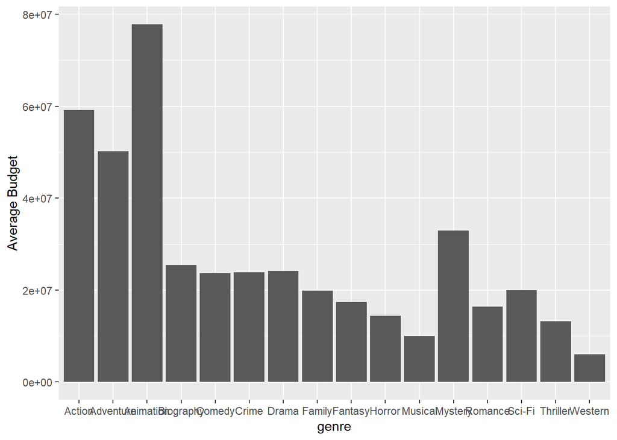

```r
movies_by_genre <- movies %>% group_by(genre) %>%
                   summarise(mean_budget = mean(budget), max_budget = max(budget), min_budget = min(budget),
                             mean_gross = mean(gross), max_gross = max(gross), min_gross = min(gross),
                             mean_profit = mean(profit), max_profit = max(profit), min_profit = min(profit)) %>%
                   arrange(mean_budget)

ggplot(data = movies_by_genre, aes(y = mean_budget, x = genre)) + geom_bar(stat="identity") + ylab("Average Budget")
```

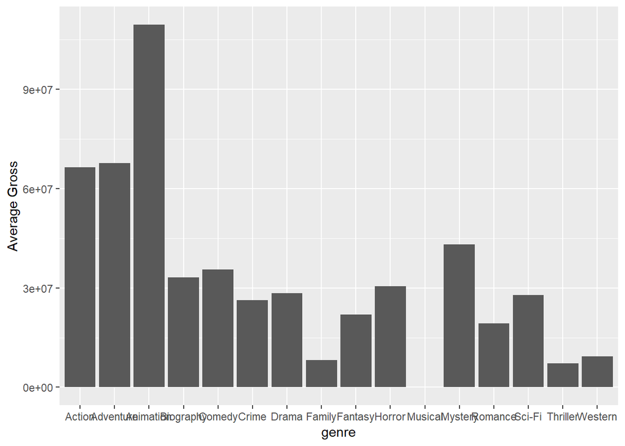

```r
ggplot(data = movies_by_genre, aes(y = mean_gross, x = genre)) + geom_bar(stat="identity") + ylab("Average Gross")
```

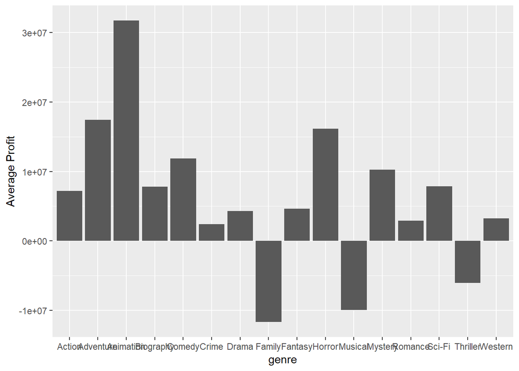

```r
ggplot(data = movies_by_genre, aes(y = mean_profit, x = genre)) + geom_bar(stat="identity") + ylab("Average Profit")
```

We want to introduce a name we came up with while doing our analysis, as we often had to refer to Budget, Gross and Profit at the same time. We shortened these three variables into the abbreviation BGP. You will see this name pop up in this file every once in a while.

## Movies by studio

```r
movies_company <- movies %>% group_by(company) %>% summarise(mean_score = mean(score), mean_budget = mean(budget), mean_gross = mean(gross), number = length(name)) %>% arrange(desc(mean_budget)) %>% filter(number > 6)

movies_company %>% select(company, mean_score) %>% arrange(desc(mean_score))
```

```
## # A tibble: 73 x 2
##    company                          mean_score
##    <fct>                                 <dbl>
##  1 Pixar Animation Studios                7.78
##  2 Marvel Studios                         7.6
##  3 Walt Disney Animation Studios          7.36
##  4 Paramount Vantage                      7.35
##  5 PolyGram Filmed Entertainment          7.04
##  6 Icon Entertainment International       6.96
##  7 The Weinstein Company                  6.95
##  8 BBC Films                              6.95
##  9 DreamWorks Animation                   6.92
## 10 Endgame Entertainment                  6.91
## # ... with 63 more rows
```

```r
movies_company %>% select(company, mean_budget, mean_gross) %>% arrange(desc(mean_gross)) %>% head()
```

```
## # A tibble: 6 x 3
##   company                         mean_budget mean_gross
##   <fct>                                 <dbl>      <dbl>
## 1 Marvel Studios                   203571429. 381663254.
## 2 Pixar Animation Studios          130083333. 270168732.
## 3 Walt Disney Animation Studios    161428571. 193716647.
## 4 DreamWorks Animation             125480000  165758976.
## 5 Twentieth Century Fox Animation   91000000  147565668.
## 6 Walt Disney Pictures              84957303. 113554799.
```

```r
movies_company %>% select(company, number) %>% arrange(desc(number))
```

```
## # A tibble: 73 x 2
##    company                                number
##    <fct>                                   <int>
##  1 Universal Pictures                        265
##  2 Warner Bros.                              257
##  3 Paramount Pictures                        222
##  4 Twentieth Century Fox Film Corporation    174
##  5 New Line Cinema                           145
##  6 Columbia Pictures Corporation             137
##  7 Columbia Pictures                         108
##  8 Touchstone Pictures                        94
##  9 Walt Disney Pictures                       89
## 10 Metro-Goldwyn-Mayer (MGM)                  79
## # ... with 63 more rows
```

## Most liked movie and director

```r
str(movies)
```

```
## 'data.frame':    4638 obs. of  16 variables:
##  $ budget  : int  8000000 6000000 15000000 18500000 9000000 6000000 25000000 6000000 9000000 15000000 ...
##  $ company : Factor w/ 2179 levels "\"DIA\" Productions GmbH & Co. KG",..: 665 1683 1683 2068 2124 1159 1161 763 1683 1936 ...
##  $ country : Factor w/ 57 levels "Argentina","Aruba",..: 56 56 56 56 56 54 54 56 56 56 ...
##  $ director: Factor w/ 2759 levels "A.R. Murugadoss",..: 2200 1304 2652 1073 2129 1955 1214 590 1011 559 ...
##  $ genre   : Factor w/ 17 levels "Action","Adventure",..: 2 5 1 1 2 7 2 7 5 7 ...
##  $ gross   : int  52287414 70136369 179800601 85160248 18564613 138530565 12729917 8551228 40471663 40456565 ...
##  $ name    : Factor w/ 6731 levels "'71","'night, Mother",..: 4671 1829 6210 299 1880 3911 2890 781 3969 5312 ...
##  $ rating  : Factor w/ 13 levels "B","B15","G",..: 9 8 7 9 7 9 7 9 8 9 ...
##  $ released: Factor w/ 2403 levels "1/1/2004","1/1/2014",..: 2083 1585 1410 1837 1984 961 1684 267 932 2029 ...
##  $ runtime : int  89 103 110 137 90 120 101 120 96 96 ...
##  $ score   : num  8.1 7.8 6.9 8.4 6.9 8.1 7.4 7.8 6.8 7.5 ...
##  $ star    : Factor w/ 2504 levels "'Weird Al' Yankovic",..: 2458 1609 2349 2197 1146 372 529 928 1734 1043 ...
##  $ votes   : int  299174 264740 236909 540152 36636 317585 102879 146768 60565 129698 ...
##  $ writer  : Factor w/ 4199 levels "'Weird Al' Yankovic",..: 3728 1980 1861 1637 2559 2996 981 901 1980 1342 ...
##  $ year    : int  1986 1986 1986 1986 1986 1986 1986 1986 1986 1986 ...
##  $ profit  : int  44287414 64136369 164800601 66660248 9564613 132530565 -12270083 2551228 31471663 25456565 ...
```

```r
movies %>% arrange(desc(score)) %>% select(name, director, score, gross) %>% head()
```

```
##                                            name          director score
## 1                      The Shawshank Redemption    Frank Darabont   9.3
## 2                               The Dark Knight Christopher Nolan   9.0
## 3                              Schindler's List  Steven Spielberg   8.9
## 4                                  Pulp Fiction Quentin Tarantino   8.9
## 5 The Lord of the Rings: The Return of the King     Peter Jackson   8.9
## 6                                  Forrest Gump   Robert Zemeckis   8.8
##       gross
## 1  28341469
## 2 534858444
## 3  96067179
## 4 107928762
## 5 377845905
## 6 330252182
```

```r
movies %>% arrange(desc(gross)) %>% select(name, director, score, gross) %>% head()
```

```
##                           name          director score     gross
## 1 Star Wars: The Force Awakens       J.J. Abrams   8.1 936662225
## 2                       Avatar     James Cameron   7.8 760507625
## 3                      Titanic     James Cameron   7.8 658672302
## 4               Jurassic World   Colin Trevorrow   7.0 652270625
## 5                 The Avengers       Joss Whedon   8.1 623357910
## 6              The Dark Knight Christopher Nolan   9.0 534858444
```

## Analysis by company

```r
movies %>% group_by(company) %>% summarize(revenue = mean(gross-budget), score = mean(score), number = length(name)) %>% arrange(desc(revenue)) %>% head()
```

```
## # A tibble: 6 x 4
##   company                       revenue score number
##   <fct>                           <dbl> <dbl>  <int>
## 1 Lucasfilm                  307162500.  7.27      6
## 2 Illumination Entertainment 262045770   6.4       1
## 3 Dentsu                     195329045   7.1       1
## 4 Fairview Entertainment     189001123   7.5       1
## 5 Marvel Studios             178091826.  7.6       7
## 6 Color Force                169382865.  6.78      4
```

```r
movies %>% group_by(company) %>% summarize(score = mean(score), number = length(name)) %>% arrange(desc(score)) %>% head()
```

```
## # A tibble: 6 x 3
##   company                       score number
##   <fct>                         <dbl>  <int>
## 1 O2 Filmes                       8.7      1
## 2 Cecchi Gori Pictures            8.6      1
## 3 Melampo Cinematografica         8.6      1
## 4 Strong Heart/Demme Production   8.6      1
## 5 Tokuma Shoten                   8.6      1
## 6 Cristaldifilm                   8.5      1
```

```r
movies %>% group_by(company) %>% summarize(score = mean(score), number = length(name)) %>% filter(number > 2) %>% arrange(desc(score)) %>% head()
```

```
## # A tibble: 6 x 3
##   company                 score number
##   <fct>                   <dbl>  <int>
## 1 Pixar Animation Studios  7.78     12
## 2 Les Films Alain Sarde    7.77      3
## 3 CJ Entertainment         7.7       4
## 4 Studio Ghibli            7.65      4
## 5 Circle Films             7.63      3
## 6 Marvel Studios           7.6       7
```

```r
movies %>% group_by(company) %>% summarize(revenue = mean(gross-budget), score = mean(score), number = length(name)) %>% filter(number > 2) %>% arrange(desc(revenue)) %>% head()
```

```
## # A tibble: 6 x 4
##   company                    revenue score number
##   <fct>                        <dbl> <dbl>  <int>
## 1 Lucasfilm               307162500.  7.27      6
## 2 Marvel Studios          178091826.  7.6       7
## 3 Color Force             169382865.  6.78      4
## 4 Pixar Animation Studios 140085398.  7.78     12
## 5 Icon Productions        105179227.  6.5       3
## 6 Hughes Entertainment     97969262   6.6       3
```

## Most popular stars and directors

```r
movies %>% group_by(star) %>% filter(n() > 4) %>% summarize(mean_budget = mean(budget)) %>% arrange(desc(mean_budget)) %>% head(5)
```

```
## # A tibble: 5 x 2
##   star              mean_budget
##   <fct>                   <dbl>
## 1 Daniel Craig       141875000
## 2 Chris Hemsworth    111666667.
## 3 Andrew Garfield    104800000
## 4 Robert Downey Jr.  101000000
## 5 Ian McKellen       100500000
```

```r
movies %>% group_by(star) %>% filter(n() > 4) %>% summarize(mean_gross = mean(gross)) %>% arrange(desc(mean_gross)) %>% head(5)
```

```
## # A tibble: 5 x 2
##   star              mean_gross
##   <fct>                  <dbl>
## 1 Jennifer Lawrence 205768484.
## 2 Daniel Radcliffe  196137991.
## 3 Robert Downey Jr. 191848744.
## 4 Mike Myers        170942698.
## 5 Tobey Maguire     166910039.
```

```r
movies %>% group_by(star) %>% filter(n() > 4) %>% summarize(mean_profit = mean(profit)) %>% arrange(desc(mean_profit)) %>% head(5)
```

```
## # A tibble: 5 x 2
##   star              mean_profit
##   <fct>                   <dbl>
## 1 Jennifer Lawrence  121780984.
## 2 Mike Myers          96026032.
## 3 Daniel Radcliffe    95956173.
## 4 Kristen Stewart     94912887.
## 5 Robert Downey Jr.   90848744.
```

```r
# Now we repeat the same for the director

movies %>% group_by(director) %>% summarize(observations = n(), mean_budget = mean(budget)) %>% filter(observations > 1) %>% arrange(desc(mean_budget)) %>% head(5)
```

```
## # A tibble: 5 x 3
##   director       observations mean_budget
##   <fct>                 <int>       <dbl>
## 1 Andrew Stanton            4   181000000
## 2 Gareth Edwards            2   180000000
## 3 David Yates               5   177000000
## 4 Joss Whedon               3   170000000
## 5 Alan Taylor               2   162500000
```

```r
movies %>% group_by(director) %>% summarize(observations = n(), mean_gross = mean(gross)) %>% filter(observations > 1) %>% arrange(desc(mean_gross)) %>% head(5)
```

```
## # A tibble: 5 x 3
##   director        observations mean_gross
##   <fct>                  <int>      <dbl>
## 1 George Lucas               3 388494272.
## 2 Joss Whedon                3 369292765
## 3 Gareth Edwards             2 366426696.
## 4 J.J. Abrams                5 336840977
## 5 Colin Trevorrow            2 328140791
```

```r
movies %>% group_by(director) %>% summarize(observations = n(), mean_profit = mean(profit)) %>% filter(observations > 1) %>% arrange(desc(mean_profit)) %>% head(5)
```

```
## # A tibble: 5 x 3
##   director        observations mean_profit
##   <fct>                  <int>       <dbl>
## 1 George Lucas               3  274160938.
## 2 Colin Trevorrow            2  252765791
## 3 Pierre Coffin              2  237287625
## 4 Chris Renaud               2  218707415
## 5 Joss Whedon                3  199292765
```

## Analysis by director (Not included in the paper)

```r
movies %>% group_by(director) %>% summarize(revenue = mean(gross-budget), score = mean(score), number = length(name)) %>% arrange(desc(revenue)) %>% head()
```

```
## # A tibble: 6 x 4
##   director           revenue score number
##   <fct>                <dbl> <dbl>  <int>
## 1 Tim Miller      305070709   8         1
## 2 George Lucas    274160938.  6.9       3
## 3 Kyle Balda      262045770   6.4       1
## 4 Colin Trevorrow 252765791   7         2
## 5 Pierre Coffin   237287625   7.55      2
## 6 Chris Renaud    218707415   6.5       2
```

```r
movies %>% group_by(director) %>% summarize(score = mean(score), number = length(name)) %>% arrange(desc(score)) %>% head()
```

```
## # A tibble: 6 x 3
##   director          score number
##   <fct>             <dbl>  <int>
## 1 Roberto Benigni    8.6       1
## 2 Tony Kaye          8.5       1
## 3 Majid Majidi       8.4       1
## 4 Nishikant Kamat    8.4       1
## 5 Damien Chazelle    8.35      2
## 6 Christopher Nolan  8.32      9
```

```r
movies %>% group_by(director) %>% summarize(score = mean(score), number = length(name)) %>% filter(number > 2) %>% arrange(desc(score)) %>% head()
```

```
## # A tibble: 6 x 3
##   director          score number
##   <fct>             <dbl>  <int>
## 1 Christopher Nolan  8.32      9
## 2 Pete Docter        8.2       3
## 3 Quentin Tarantino  8.16      8
## 4 Hayao Miyazaki     8.07      4
## 5 Frank Darabont     7.98      4
## 6 Denis Villeneuve   7.98      4
```

```r
movies %>% group_by(director) %>% summarize(revenue = mean(gross-budget), score = mean(score), number = length(name)) %>% filter(number > 2) %>% arrange(desc(revenue)) %>% head()
```

```
## # A tibble: 6 x 4
##   director          revenue score number
##   <fct>               <dbl> <dbl>  <int>
## 1 George Lucas   274160938.  6.9       3
## 2 Joss Whedon    199292765   7.8       3
## 3 James Cameron  194571164.  7.88      6
## 4 J.J. Abrams    179840977   7.56      5
## 5 Pete Docter    158127377   8.2       3
## 6 Andrew Adamson 130616846.  7.15      4
```

Time Miller is the most profitable director, closely followed by George Lucas. It is noticable that all very profitable directors do not have many entries in the dataset. More reknown directors like Cameron or Spielberg are also more likely to have produced movies that didn’t do so well in the box offic, which lowers their average drastically, leaving the best spots to less known directors (with the exception of George Lucas) . The most successful director based on movie rating is Roberto Benigni, followd by Tony Kaye. If we only accept Directors with 3 or more movies in the dataset, Christopher Nolan has the top spot, followed by Pete Doctor and Quentin Tarantino, all well known names in the movie industry. If we only accept Directors with a minimum of 3 movies, the highest grossing director is George Lucas, followed by Joss Wheadon and James Cameron.

# Most interesting findings:

## Relation between BGP and Runtime

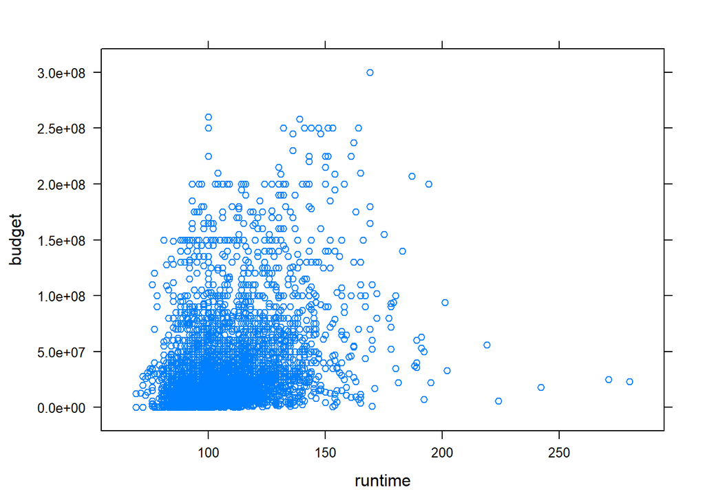

```r
xyplot(budget~runtime, data=movies)
```

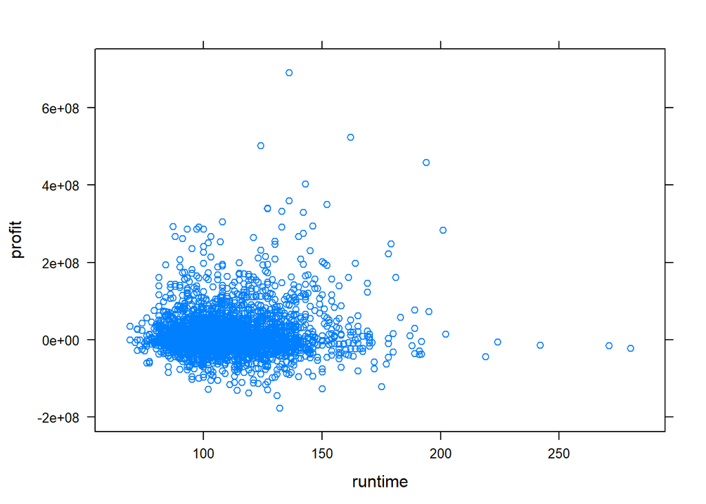

```r
xyplot(profit~runtime, data=movies)
```

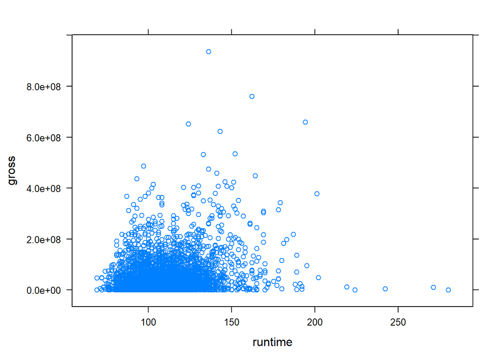

```r
xyplot(gross~runtime, data=movies)
```

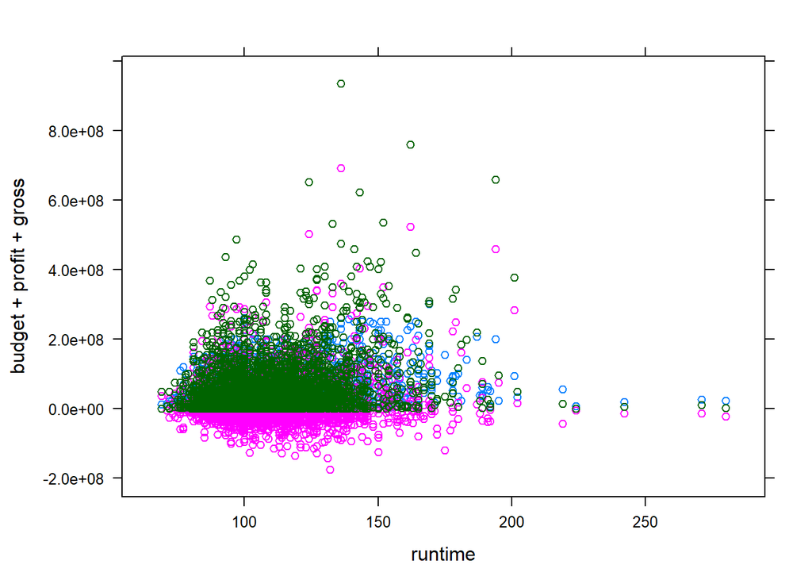

```r
xyplot(budget+profit+gross~runtime, data=movies)
```

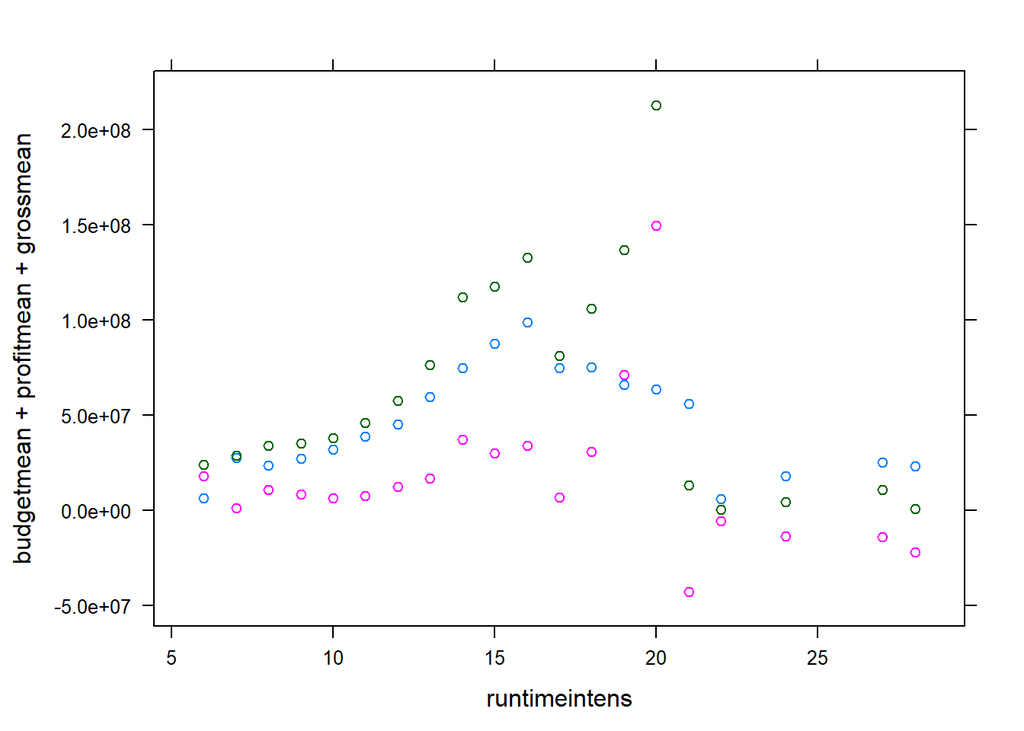

```r
#xyplot(runtime~budget, data=movies)

movies2= movies%>%mutate(runtimeintens=floor(runtime/10))%>%group_by(runtimeintens)%>%
  summarize(budgetmean=mean(budget),
            profitmean=mean(profit),
            grossmean=mean(gross),
            scoremean = mean(score),
            number = n())
xyplot(budgetmean+profitmean+grossmean~runtimeintens, data=movies2)
```

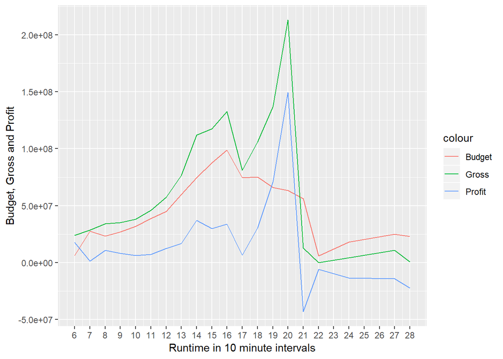

```r
ggplot(data = movies2, aes (x = runtimeintens)) +
  geom_line(aes(y = budgetmean, color = "Budget")) +
  geom_line(aes(y = profitmean, color = "Profit")) +
  geom_line(aes(y =grossmean, color = "Gross")) +
  ylab("Budget, Gross and Profit") + xlab("Runtime in 10 minute intervals") +
  scale_x_continuous(breaks = round(seq(min(movies2$runtimeintens), max(movies2$runtimeintens), by = 1),1))
```

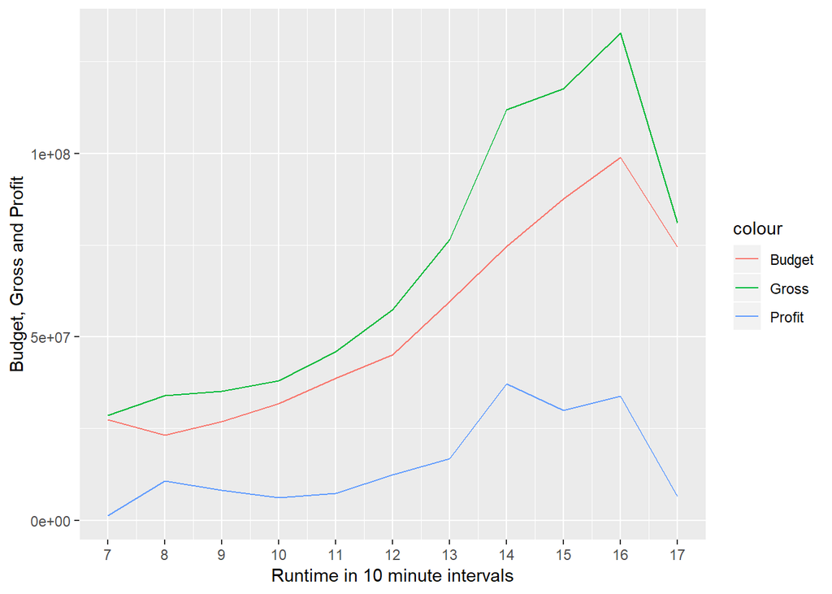

```r
# As the runtime is normally distributed, we will get rid of the very low and high values, as they would consist of only one or two movies each and do not represent the data sccurately
ggplot(data = movies2 %>% filter(number > 10), aes (x = runtimeintens)) +
  geom_line(aes(y = budgetmean, color = "Budget")) +
  geom_line(aes(y = profitmean, color = "Profit")) +
  geom_line(aes(y =grossmean, color = "Gross")) +
  ylab("Budget, Gross and Profit") + xlab("Runtime in 10 minute intervals") +
  scale_x_continuous(breaks = round(seq(min(movies2$runtimeintens), max(movies2$runtimeintens), by = 1),1))
```

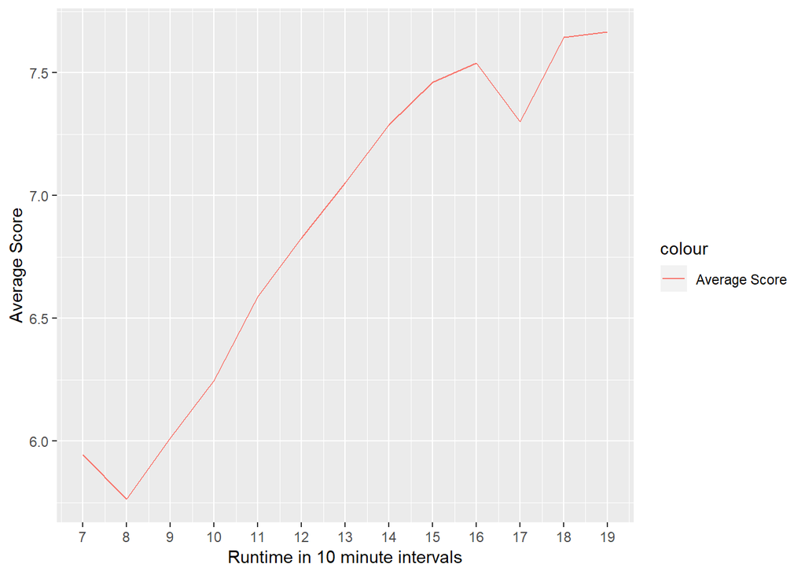

```r
ggplot(data = movies2 %>% filter(number > 5), aes (x = runtimeintens)) +
  geom_line(aes(y = scoremean, color = "Average Score")) +
  ylab("Average Score") + xlab("Runtime in 10 minute intervals") +
  scale_x_continuous(breaks = round(seq(min(movies2$runtimeintens), max(movies2$runtimeintens), by = 1),1))
```

## Relation between score and BGP

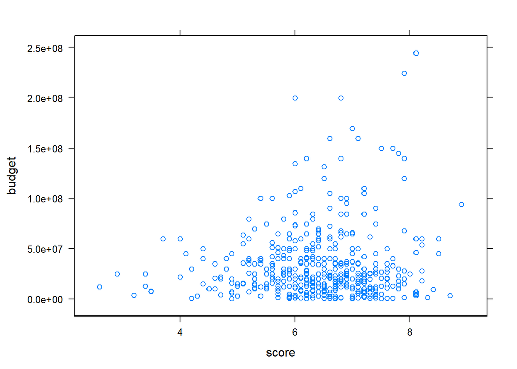

```r
#Reducing dataset size for easier visibility in exploratory plotting
movies2 = movies %>% sample_frac(0.1)

xyplot(budget~score, data=movies2)
```

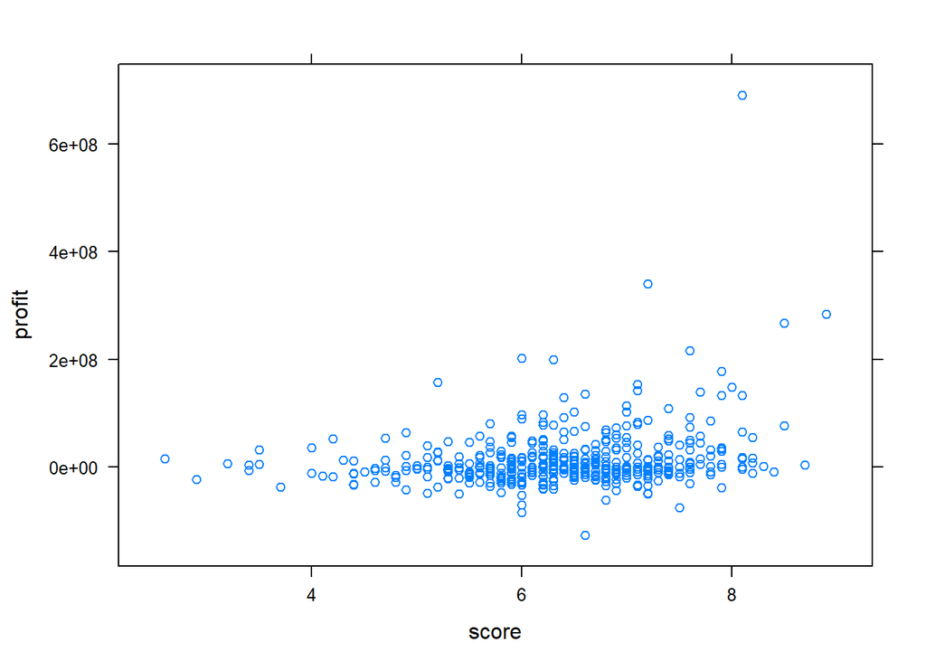

```r
xyplot(profit~score, data=movies2)
```

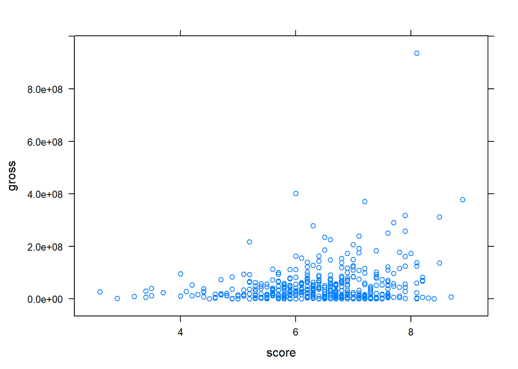

```r
xyplot(gross~score, data=movies2)
```

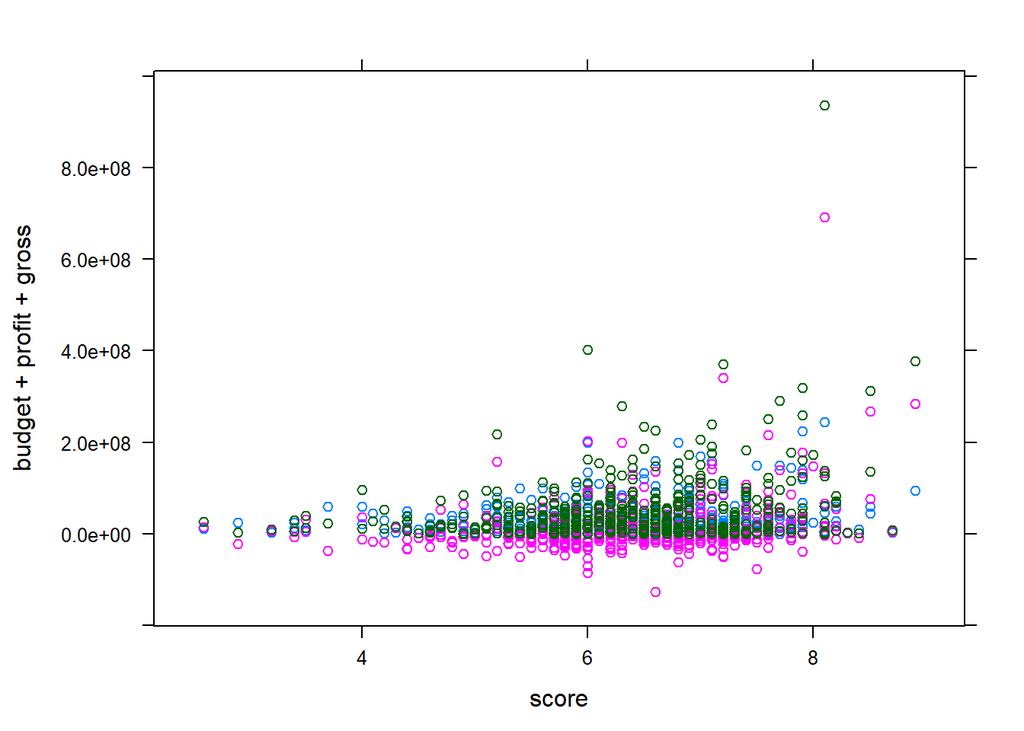

```r
xyplot(budget+profit+gross~score, data=movies2)
```

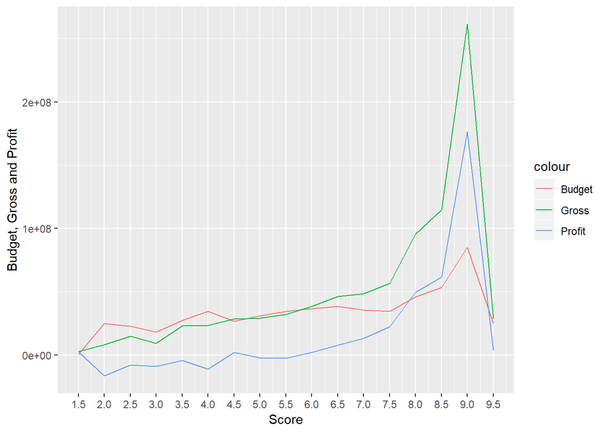

```r
movies3= movies %>% mutate(scoreround=round(score*2)/2)%>%
  group_by(scoreround)%>%summarize(budgetmean=mean(budget),
                                   profitmean=mean(profit),
                                   grossmean=mean(gross),
                                   number = n())

ggplot(data = movies3, aes (x = scoreround)) +
  geom_line(aes(y = budgetmean, color = "Budget")) +
  geom_line(aes(y = profitmean, color = "Profit")) +
  geom_line(aes(y =grossmean, color = "Gross")) +
  ylab("Budget, Gross and Profit") + xlab("Score") +
  scale_x_continuous(breaks = round(seq(min(movies3$scoreround), max(movies3$scoreround), by = 0.5),1))
```

## Genre-Runtime analysis

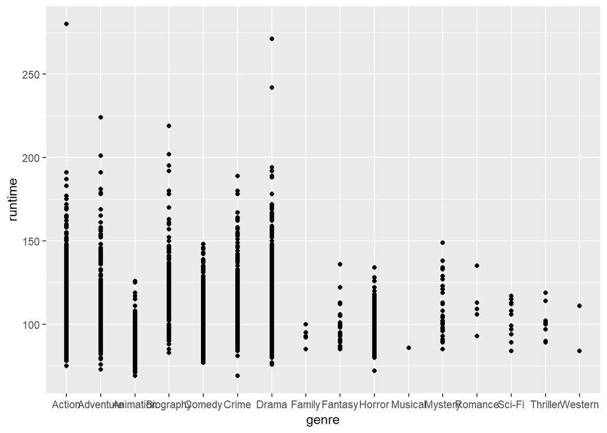

```r
movies_runtime <- movies %>% group_by(genre) %>% summarise(mean_runtime = mean(runtime))

ggplot(data = movies, aes(y=runtime)) + geom_point(aes(x=genre))
```

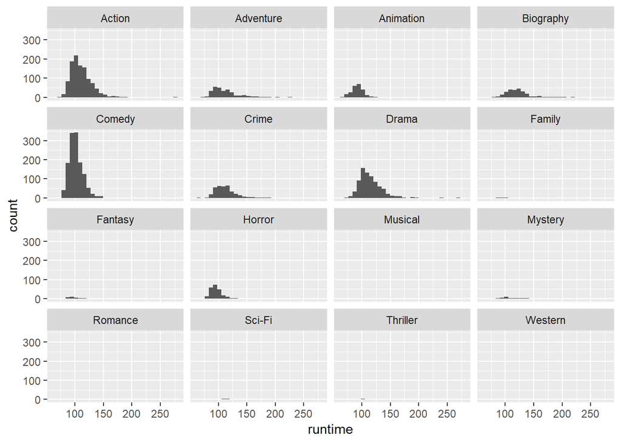

```r
ggplot(data = movies, aes(x=runtime)) + geom_histogram() + facet_wrap(movies$genre)
```

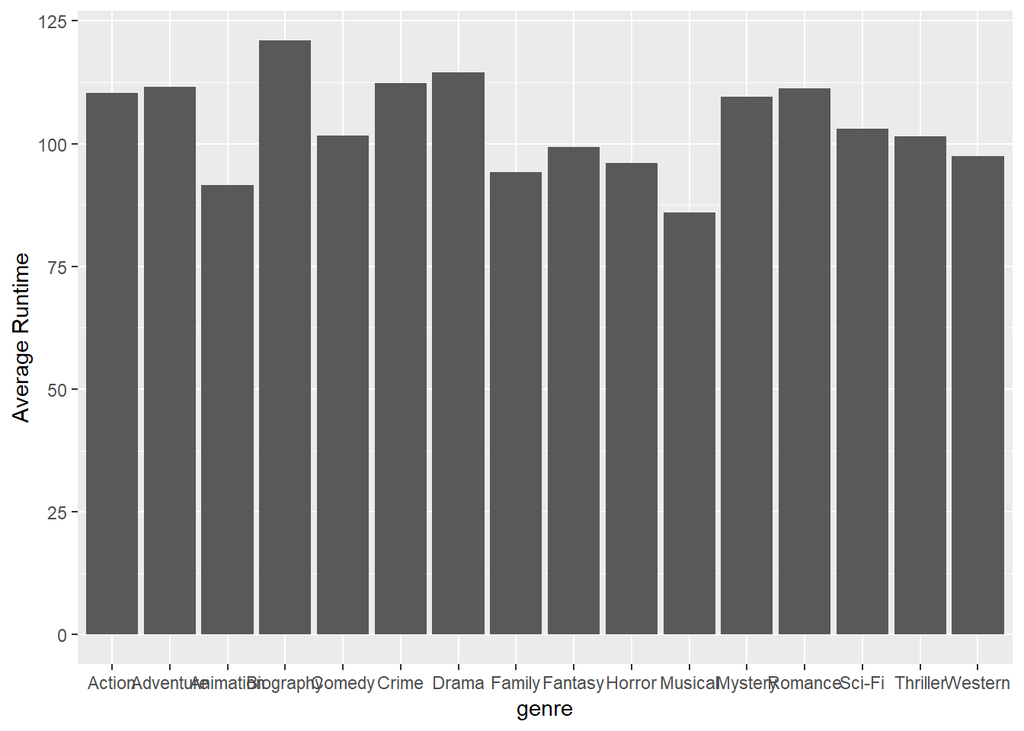

```r
ggplot(data = movies_runtime, aes(y = mean_runtime, x = genre)) + geom_bar(stat="identity") + ylab("Average Runtime")
```

## The more movies you make, the higher the BGP? (directors - stars - BGP)

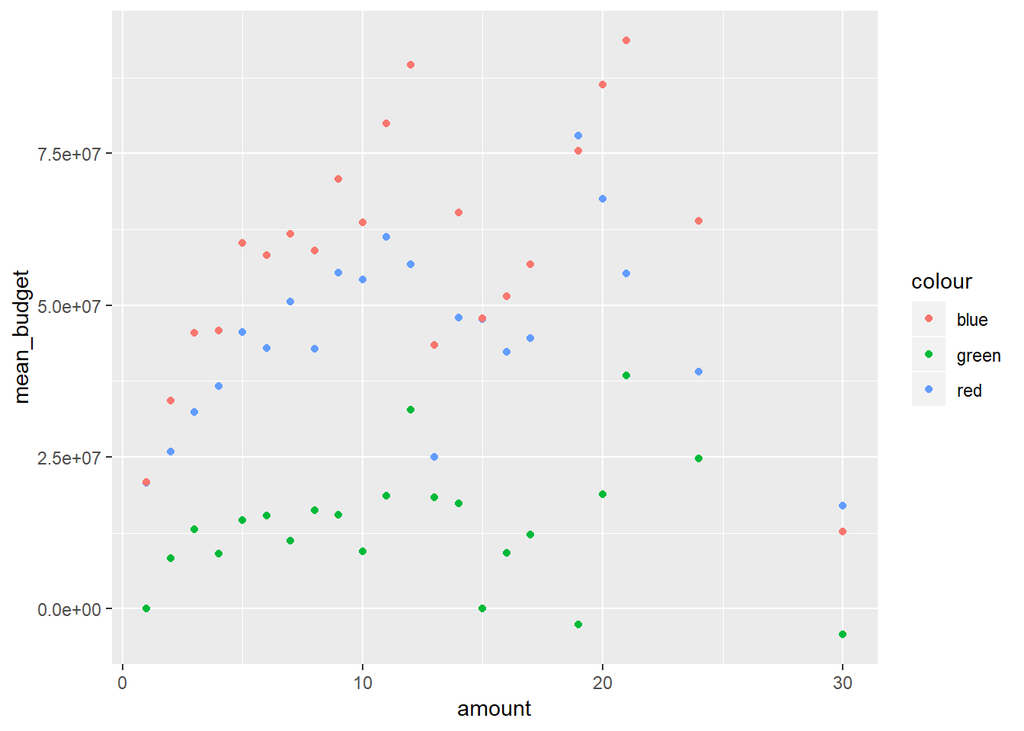

```r
movies_by_amount_director <- movies %>% group_by(director) %>%
                             summarize(amount = n(),
                                       mean_budget = mean(budget),
                                       mean_gross = mean(gross),
                                       mean_profit = mean(profit)) %>%
                             group_by(amount) %>%
                             summarize(mean_budget = mean(mean_budget),
                                       mean_gross = mean(mean_gross),
                                       mean_profit = mean(mean_profit))

movies_by_amount_stars <- movies %>% group_by(star) %>%
                          summarize(amount = n(),
                                    mean_budget = mean(budget),
                                    mean_gross = mean(gross),
                                    mean_profit = mean(profit)) %>%
                          group_by(amount) %>%
                          summarize(mean_budget = mean(mean_budget),
                                    mean_gross = mean(mean_gross),
                                    mean_profit = mean(mean_profit))


ggplot(data = movies_by_amount_director, aes(amount)) +
  geom_point(aes(y = mean_budget, color = 'red')) +
  geom_point(aes(y = mean_gross, color = 'blue')) +
  geom_point(aes( y = mean_profit, color = 'green'))
```

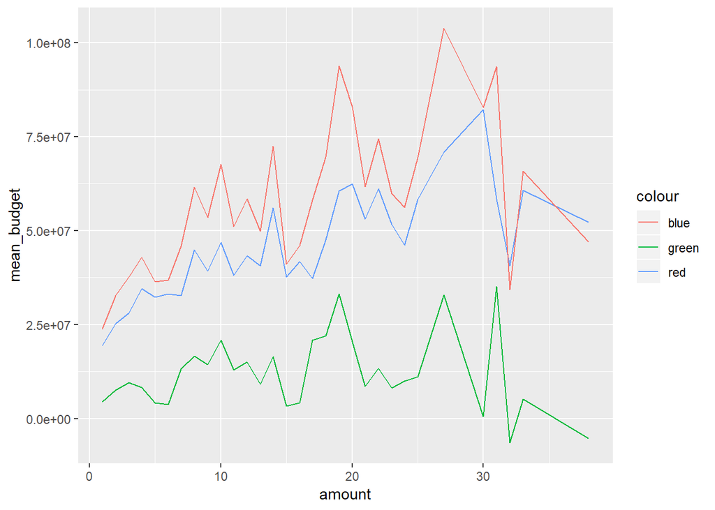

```r
ggplot(data = movies_by_amount_stars, aes(amount)) +
  geom_line(aes(y = mean_budget, color = 'red')) +
  geom_line(aes(y = mean_gross, color = 'blue')) +
  geom_line(aes( y = mean_profit, color = 'green'))
```

The result definetely has a lost of unexplanable noise associated with it, but we can also see that for the first ten movies a star or director makes, this is definetely true. We will again plot this by filtering out all other results.

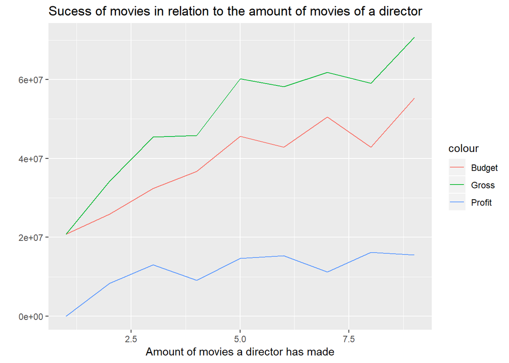

```r
# Now for only the first ten observations, as there arent many datapoints for the directors or stars
#  that have made more than 10 movies

ggplot(data = movies_by_amount_director %>% filter(amount <10), aes(amount)) +
  geom_line(aes(y = mean_budget, color = 'Budget')) +
  geom_line(aes(y = mean_gross, color = 'Gross')) +
  geom_line(aes( y = mean_profit, color = 'Profit')) +
  ggtitle("Sucess of movies in relation to the amount of movies of a director") +
  ylab("") + xlab("Amount of movies a director has made")
```

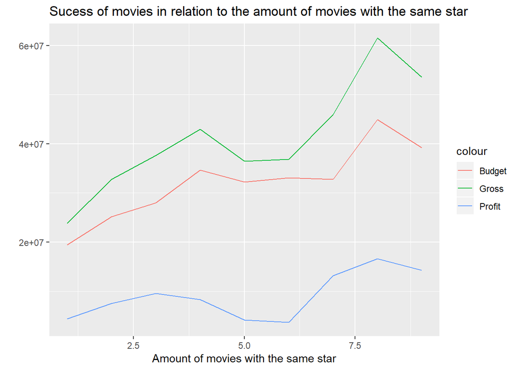

```r
ggplot(data = movies_by_amount_stars %>% filter(amount <10), aes(amount)) +
  geom_line(aes(y = mean_budget, color = 'Budget')) +
  geom_line(aes(y = mean_gross, color = 'Gross')) +
  geom_line(aes( y = mean_profit, color = 'Profit')) +
  ggtitle("Sucess of movies in relation to the amount of movies with the same star") +
  ylab("") + xlab("Amount of movies with the same star")
```

Looking at these plots, we can definetely see a clear relationship between the amount of budget and income a movie has and the amount of movies the 1. director and 2. star has already made. There also seems to be a relationship between the budget and the gross the movie ends up making, as the Budget and Gross line generally follow the same path. As these lines still have some noise, we must conclude that some very high grossing movies (outliers), influenced our outcome.

## Popular Genres by year and decade:

To be able to analyse the genres by decade, we wanted to get the most popular genres first, so the plot would remain understandable

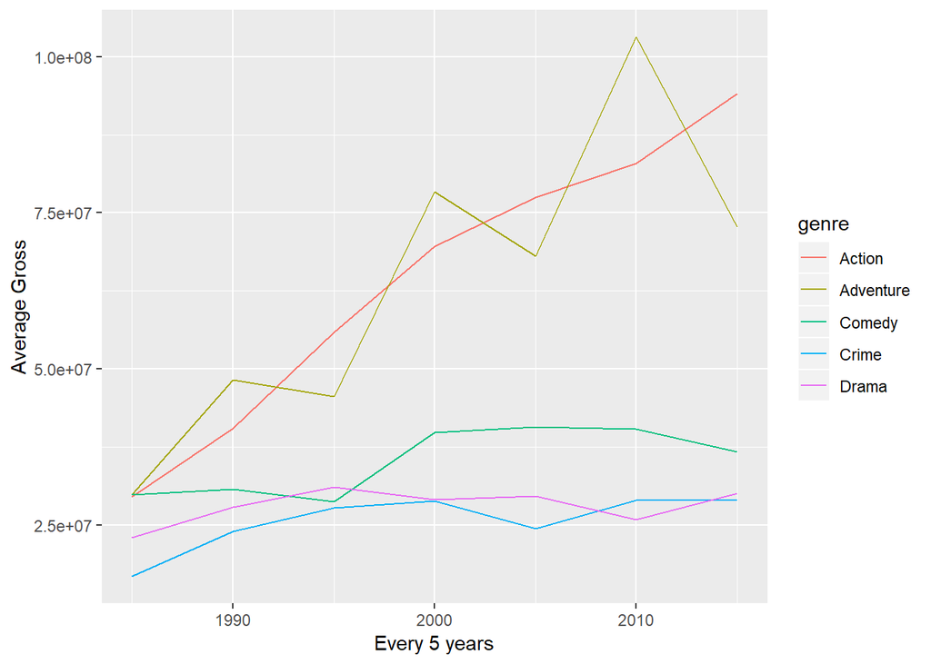

```r
movies_best_genres <- movies %>% filter(genre %in% as.character((movies %>% group_by(genre) %>% summarize(number = n()) %>% filter(number > 250))$genre))

movies_genre <- movies_best_genres %>% mutate(halfDecade = year - year %% 5 ) %>%
                group_by(halfDecade, genre) %>% summarize(number = n(), mean_score = mean(score),
                                                          mean_gross = mean(gross), mean_budget = mean(budget))

ggplot(data = movies_genre, aes(x = halfDecade, color=genre)) +
       geom_line(aes(y=mean_gross)) + ylab("Average Gross") + xlab("Every 5 years")
```

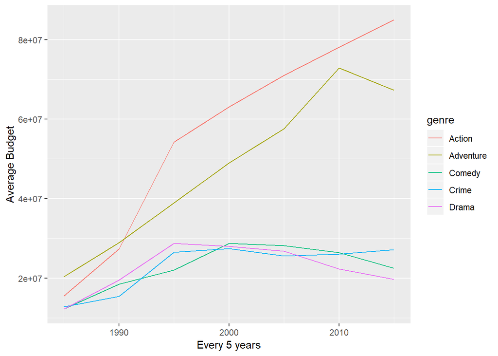

```r
ggplot(data = movies_genre, aes(x = halfDecade, color=genre)) +
       geom_line(aes(y=mean_budget)) + ylab("Average Budget") + xlab("Every 5 years")
```

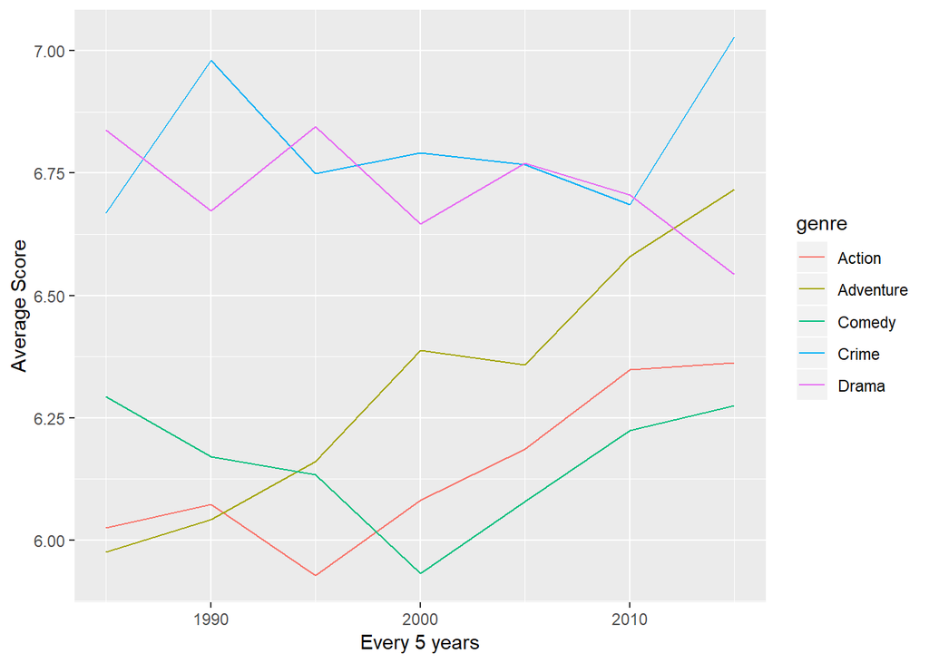

```r
ggplot(data = movies_genre, aes(x = halfDecade, color = genre)) +
       geom_line(aes(y=mean_score))+ ylab("Average Score") + xlab("Every 5 years")
```

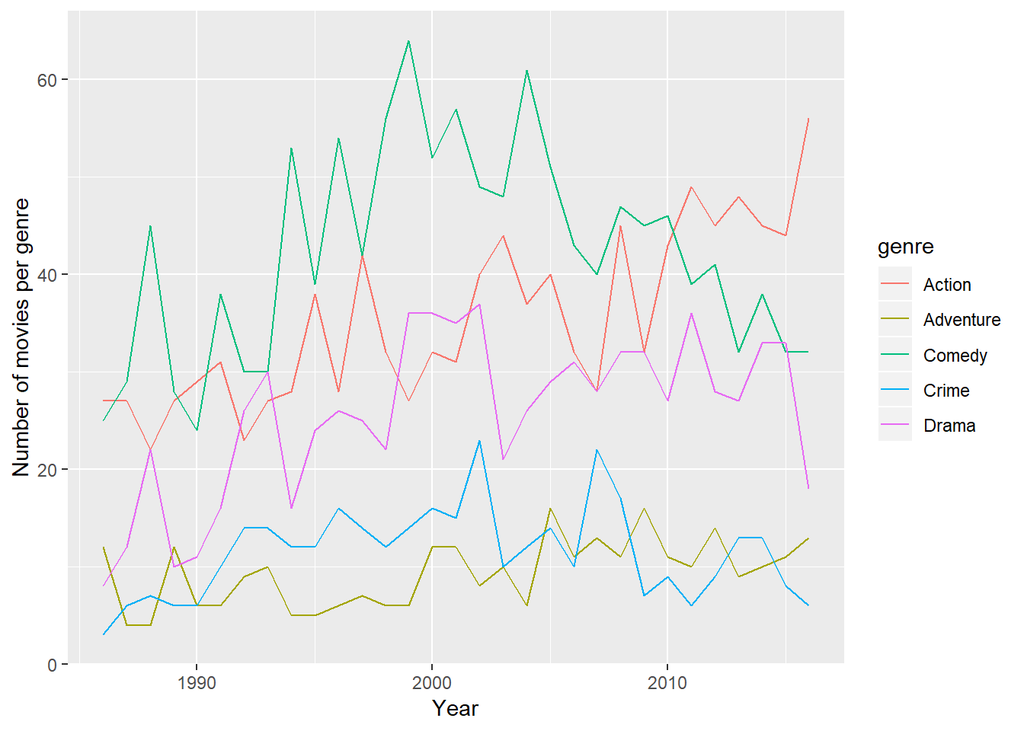

```r
ggplot(data = movies %>% filter(genre %in% as.character((movies %>% group_by(genre) %>%
                                                         summarize(number = length(name)) %>%
                                                         filter(number > 250))$genre)) %>%
              group_by(genre, year) %>% summarize(number = length(name)),
       aes(x = year, color = genre)) +
       geom_line(aes(y=number)) + ylab("Number of movies per genre") + xlab("Year")
```

# Analysis using linear regression

```r
summary(lm(data = movies, formula = gross ~ budget))
```

```
##
## Call:
## lm(formula = gross ~ budget, data = movies)
##
## Residuals:
##        Min         1Q     Median         3Q        Max
## -214204912  -20252048   -7352996   10704199  655018759
##
## Coefficients:
##              Estimate Std. Error t value Pr(>|t|)
## (Intercept) 5.306e+06  9.624e+05   5.513 3.72e-08 ***
## budget      1.128e+00  1.786e-02  63.152  < 2e-16 ***
## ---
## Signif. codes:  0 '***' 0.001 '**' 0.01 '*' 0.05 '.' 0.1 ' ' 1
##
## Residual standard error: 48610000 on 4636 degrees of freedom
## Multiple R-squared:  0.4624, Adjusted R-squared:  0.4623
## F-statistic:  3988 on 1 and 4636 DF,  p-value: < 2.2e-16
```

```r
summary(lm(data = movies, formula = gross ~ genre))
```

```
##
## Call:
## lm(formula = gross ~ genre, data = movies)
##
## Residuals:
##        Min         1Q     Median         3Q        Max
## -108874667  -30532114  -17580531   13671799  870268863
##
## Coefficients:
##                 Estimate Std. Error t value Pr(>|t|)
## (Intercept)     66393362    1892495  35.082  < 2e-16 ***
## genreAdventure   1299395    4136145   0.314 0.753417
## genreAnimation  43150581    4557389   9.468  < 2e-16 ***
## genreBiography -33142187    4477792  -7.401 1.59e-13 ***
## genreComedy    -30814403    2566360 -12.007  < 2e-16 ***
## genreCrime     -40100998    3825968 -10.481  < 2e-16 ***
## genreDrama     -37942803    2923202 -12.980  < 2e-16 ***
## genreFamily    -58176389   25682679  -2.265 0.023547 *
## genreFantasy   -44391301   11802945  -3.761 0.000171 ***
## genreHorror    -35851088    4565653  -7.852 5.04e-15 ***
## genreMusical   -66348605   62766969  -1.057 0.290538
## genreMystery   -23251952   11425973  -2.035 0.041907 *
## genreRomance   -47060798   28121233  -1.673 0.094297 .
## genreSci-Fi    -38591947   19010781  -2.030 0.042413 *
## genreThriller  -59180242   22261972  -2.658 0.007879 **
## genreWestern   -57133815   44403119  -1.287 0.198261
## ---
## Signif. codes:  0 '***' 0.001 '**' 0.01 '*' 0.05 '.' 0.1 ' ' 1
##
## Residual standard error: 62740000 on 4622 degrees of freedom
## Multiple R-squared:  0.1073, Adjusted R-squared:  0.1044
## F-statistic: 37.03 on 15 and 4622 DF,  p-value: < 2.2e-16
```

```r
summary(lm(data = movies, formula = gross ~ score))
```

```
##
## Call:
## lm(formula = gross ~ score, data = movies)
##
## Residuals:
##       Min        1Q    Median        3Q       Max
## -76127428 -38597095 -16330012  14514657 864342726
##
## Coefficients:
##              Estimate Std. Error t value Pr(>|t|)
## (Intercept) -49596563    6032509  -8.222 2.58e-16 ***
## score        15051366     937277  16.059  < 2e-16 ***
## ---
## Signif. codes:  0 '***' 0.001 '**' 0.01 '*' 0.05 '.' 0.1 ' ' 1
##
## Residual standard error: 64530000 on 4636 degrees of freedom
## Multiple R-squared:  0.05269,    Adjusted R-squared:  0.05249
## F-statistic: 257.9 on 1 and 4636 DF,  p-value: < 2.2e-16
```

```r
summary(lm(data = movies, formula = gross ~ runtime))
```

```
##
## Call:
## lm(formula = gross ~ runtime, data = movies)
##
## Residuals:
##        Min         1Q     Median         3Q        Max
## -205937416  -34329345  -18512713   12953771  864125326
##
## Coefficients:
##              Estimate Std. Error t value Pr(>|t|)
## (Intercept) -54163510    5701439   -9.50   <2e-16 ***
## runtime        931621      52262   17.83   <2e-16 ***
## ---
## Signif. codes:  0 '***' 0.001 '**' 0.01 '*' 0.05 '.' 0.1 ' ' 1
##
## Residual standard error: 64140000 on 4636 degrees of freedom
## Multiple R-squared:  0.06415,    Adjusted R-squared:  0.06395
## F-statistic: 317.8 on 1 and 4636 DF,  p-value: < 2.2e-16
```

```r
summary(lm(data = movies2, formula = gross ~ rating))
```

```
##
## Call:
## lm(formula = gross ~ rating, data = movies2)
##
## Residuals:
##       Min        1Q    Median        3Q       Max
## -90427053 -28839365 -18039321  13722600 866568116
##
## Coefficients:
##                      Estimate Std. Error t value Pr(>|t|)
## (Intercept)          93996992   26403598   3.560  0.00041 ***
## ratingNC-17         -89996688   74680654  -1.205  0.22879
## ratingNOT RATED     -92962628   56010491  -1.660  0.09766 .
## ratingNot specified -90316096   56010491  -1.612  0.10755
## ratingPG            -39732079   27624204  -1.438  0.15103
## ratingPG-13         -23902882   27004733  -0.885  0.37655
## ratingR             -65104747   26814803  -2.428  0.01557 *
## ratingUNRATED       -93428235   48206155  -1.938  0.05323 .
## ---
## Signif. codes:  0 '***' 0.001 '**' 0.01 '*' 0.05 '.' 0.1 ' ' 1
##
## Residual standard error: 69860000 on 456 degrees of freedom
## Multiple R-squared:  0.07861,    Adjusted R-squared:  0.06446
## F-statistic: 5.558 on 7 and 456 DF,  p-value: 3.713e-06
```

```r
summary(lm(data = movies, formula = score ~ year))
```

```
##
## Call:
## lm(formula = score ~ year, data = movies)
##
## Residuals:
##     Min      1Q  Median      3Q     Max
## -4.9409 -0.5821  0.0693  0.6885  3.0060
##
## Coefficients:
##              Estimate Std. Error t value Pr(>|t|)
## (Intercept) -8.354206   3.507621  -2.382   0.0173 *
## year         0.007346   0.001752   4.194 2.79e-05 ***
## ---
## Signif. codes:  0 '***' 0.001 '**' 0.01 '*' 0.05 '.' 0.1 ' ' 1
##
## Residual standard error: 1.009 on 4636 degrees of freedom
## Multiple R-squared:  0.00378,    Adjusted R-squared:  0.003565
## F-statistic: 17.59 on 1 and 4636 DF,  p-value: 2.793e-05
```

```r
summary(lm(data = movies, formula = score ~ rating))
```

```
##
## Call:
## lm(formula = score ~ rating, data = movies)
##
## Residuals:
##     Min      1Q  Median      3Q     Max
## -4.6055 -0.5896  0.0561  0.7104  2.8104
##
## Coefficients:
##                      Estimate Std. Error t value Pr(>|t|)
## (Intercept)          6.481000   0.099929  64.856  < 2e-16 ***
## ratingNC-17         -0.103222   0.347764  -0.297 0.766620
## ratingNOT RATED      0.361105   0.190432   1.896 0.057991 .
## ratingNot specified  0.719000   0.509541   1.411 0.158290
## ratingPG            -0.375537   0.107243  -3.502 0.000467 ***
## ratingPG-13         -0.237054   0.103080  -2.300 0.021510 *
## ratingR              0.008631   0.102129   0.085 0.932657
## ratingUNRATED        0.209000   0.244776   0.854 0.393236
## ---
## Signif. codes:  0 '***' 0.001 '**' 0.01 '*' 0.05 '.' 0.1 ' ' 1
##
## Residual standard error: 0.9993 on 4630 degrees of freedom
## Multiple R-squared:  0.02462,    Adjusted R-squared:  0.02315
## F-statistic:  16.7 on 7 and 4630 DF,  p-value: < 2.2e-16
```

```r
summary(lm(data = movies, formula = score ~ budget))
```

```
##
## Call:
## lm(formula = score ~ budget, data = movies)
##
## Residuals:
##     Min      1Q  Median      3Q     Max
## -4.7900 -0.5961  0.0737  0.6998  2.9644
##
## Coefficients:
##              Estimate Std. Error t value Pr(>|t|)
## (Intercept) 6.289e+00  1.997e-02 314.998  < 2e-16 ***
## budget      1.861e-09  3.705e-10   5.023 5.26e-07 ***
## ---
## Signif. codes:  0 '***' 0.001 '**' 0.01 '*' 0.05 '.' 0.1 ' ' 1
##
## Residual standard error: 1.008 on 4636 degrees of freedom
## Multiple R-squared:  0.005414,   Adjusted R-squared:  0.005199
## F-statistic: 25.24 on 1 and 4636 DF,  p-value: 5.265e-07
```

```r
summary(lm(data = movies, formula = score ~ gross))
```

```
##
## Call:
## lm(formula = score ~ gross, data = movies)
##
## Residuals:
##     Min      1Q  Median      3Q     Max
## -4.7048 -0.5787  0.0707  0.6872  3.0058
##
## Coefficients:
##              Estimate Std. Error t value Pr(>|t|)
## (Intercept) 6.195e+00  1.760e-02  352.00   <2e-16 ***
## gross       3.501e-09  2.180e-10   16.06   <2e-16 ***
## ---
## Signif. codes:  0 '***' 0.001 '**' 0.01 '*' 0.05 '.' 0.1 ' ' 1
##
## Residual standard error: 0.9842 on 4636 degrees of freedom
## Multiple R-squared:  0.05269,    Adjusted R-squared:  0.05249
## F-statistic: 257.9 on 1 and 4636 DF,  p-value: < 2.2e-16
```

```r
summary(lm(data = movies, formula = score ~ runtime))
```

```
##
## Call:
## lm(formula = score ~ runtime, data = movies)
##
## Residuals:
##     Min      1Q  Median      3Q     Max
## -4.2699 -0.5244  0.0652  0.6217  2.6021
##
## Coefficients:
##              Estimate Std. Error t value Pr(>|t|)
## (Intercept) 3.8391121  0.0816956   46.99   <2e-16 ***
## runtime     0.0233951  0.0007489   31.24   <2e-16 ***
## ---
## Signif. codes:  0 '***' 0.001 '**' 0.01 '*' 0.05 '.' 0.1 ' ' 1
##
## Residual standard error: 0.919 on 4636 degrees of freedom
## Multiple R-squared:  0.1739, Adjusted R-squared:  0.1737
## F-statistic:   976 on 1 and 4636 DF,  p-value: < 2.2e-16
```

```r
summary(lm(data = movies, formula = budget ~ score))
```

```
##
## Call:
## lm(formula = budget ~ score, data = movies)
##
## Residuals:
##       Min        1Q    Median        3Q       Max
## -41910155 -25854412 -12918101  10818591 261691215
##
## Coefficients:
##             Estimate Std. Error t value Pr(>|t|)
## (Intercept) 17656690    3726745   4.738 2.22e-06 ***
## score        2908746     579028   5.023 5.26e-07 ***
## ---
## Signif. codes:  0 '***' 0.001 '**' 0.01 '*' 0.05 '.' 0.1 ' ' 1
##
## Residual standard error: 39870000 on 4636 degrees of freedom
## Multiple R-squared:  0.005414,   Adjusted R-squared:  0.005199
## F-statistic: 25.24 on 1 and 4636 DF,  p-value: 5.265e-07
```

[figure not shown]

```r
pairs(movies)
```